# Computational Economics: Unconstrained Optimization

Florian Oswald

Sciences Po, 2016

# Some Taxonomy and Initial Examples

- In most of the examples to follow, we talk about *minimization* of a function $f$. Everything we do also applies to maximization, since $\min_x f(x) = \max_x -f(x)$.
- Here is a generic optimization problem:
  $$\min_{x\in\mathbb{R}^n} f(x) \quad s.t.\quad \begin{array} c_i(x) = 0, & i\in E \\
  c_i(x) \geq 0, & i\in I \end{array}$$
- This is a general way of writing an optimization problem. E are all indices as equality constraints, I are all inequality constraints.
- An example of such a problem might be
  $$\min (x_1 -2)^2 + (x_2 -1)^2 \quad s.t.\quad \begin{array} x_{1}^2 -x_2 \leq 0 \\
  x_1 +x_2 \leq 2 \end{array}$$
- Here is a picture of that problem taken from the textbook (Nocedal and Wright 2006) ( for copyright reasons, I cannot show this in the online version of the slides. ):

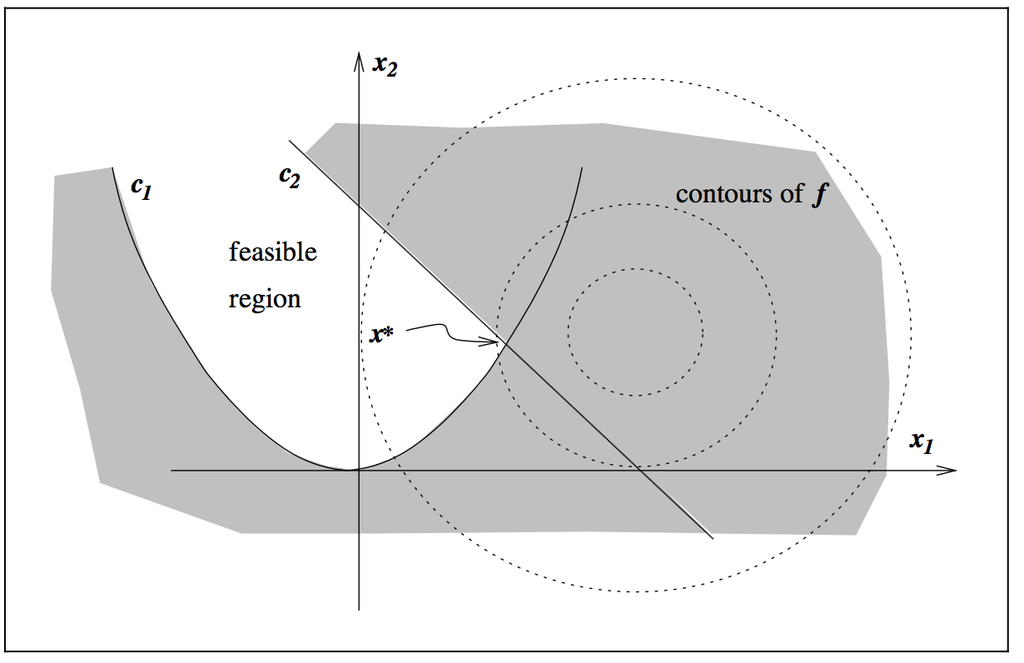

Figure 1.1 in (Nocedal and Wright 2006)

# Kinds of problems considered

- Don't talk about stochastic optimization methods:
  - Simluated Annealing
  - MCMC
  - other Stochastic Search Methods
  - A gentle introduction is (Robert and Casella 2009)

# Transportation Problem

> A chemical company has two factories $F_1,F_2$ and a dozen retail outlets $R_1,\dots,R_{12}$. Each factory $i$ can produce at most $a_i$ tons of output each week. Each retail outlet $j$ has a weekly demand of $b_j$ tons per week. The cost of shipping from $F_i$ to $R_j$ is given by $c_{ij}$. How much of the product to ship from each factory to each outlet, minimize cost, and satisfy all constraints? let's call $x_{ij}$ the number of tons shipped from $i$ to $j$.

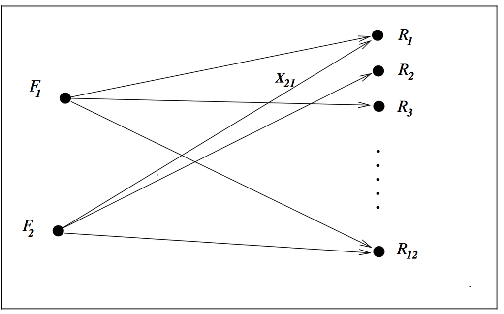

Figure 1.2 in (Nocedal and Wright 2006)

- A mathematical formulation of this problem is
  $$\begin{align}
  \min \sum_{ij} c_{ij} x_{ij} \\
  \text{subject to} \sum_{j=1}^{12} x_{ij} \leq a_i,\quad i=1,2 \\
  \sum_{i=1}^2 x_{ij} \geq b_j,\quad j=1,\dots,12 \\
  x_{ij} \geq 0, \quad i=1,2,j=1,\dots,12
  \end{align}$$
- This is called a *linear programming* problem, because both objective function and all constrains are linear.
- With any of those being nonlinear, we would call this a non-linear problem.

# Constrained vs Unconstrained

- There are many applications of both in economics.
- Unconstrained: maximimum likelihood
- Constrained: MPEC
- It is sometimes possible to transform a constrained problem into an unconstrained one.

# Convexity

- Convex problems are easier to solve.
- What is convex?

> A set $S\in\mathbb{R}^n$ is convex if the straight line segment connecting any two points in $S$ lies entirely inside $S$. A function $f$ is a convex function, if its domain $S$ is a convex set, and for any two points $x,y \in S$, we have that
> $$f(\alpha x + (1-\alpha)y) \leq \alpha f(x) + (1-\alpha) f(y)$$
> for all $\alpha \in [0,1]$
- Simple instances of convex sets are the unit ball $\{y \in \mathbb{R}^n, \Vert y\Vert_2 \leq 1\}$, and any set defined by linear equalities and inequalities.
- *convex Programming* describes a special case of the introductory minimizatin problem where
  - the objective function is convex,
  - the equality constrains are linear, and
  - the inequality constraints are concave.

# Optimization Algorithms

- All of the algorithms we are going to see employ some kind of *iterative* proceedure.
- They try to improve the value of the objective function over successive steps.
- The way the algorithm goes about generating the next step is what distinguishes algorithms from one another.
  - Some algos only use the objective function
  - Some use both objective and gradients
  - Some add the Hessian
  - and many variants more

## Desirable Features of any Algorithm

- Robustness: We want good performance on a wide variety of problems in their class, and starting from *all* reasonable starting points.
- Efficiency: They should be fast and not use an excessive amount of memory.
- Accuracy: They should identify the solution with high precision.

## A Word of Caution

- You should **not** normally attempt to write a numerical optimizer for yourself.
- Entire generations of Applied Mathematicians and other numerical pro's have worked on those topics before you, so you should use their work.
  - Any optimizer you could come up with is probably going to perform below par, and be highly likely to contain mistakes.
  - Don't reinvent the wheel.
- That said, it's very important that we understand some basics about the main algorithms, because your task is **to choose from the wide array of available ones**.

# Unconstrained Optimization: What is a solution?

- A typical unconstrained optimization problem will look something like this:
  $$\min_x f(x),\quad x\in \mathbb{R}^n$$
  and where $f : \mathbb{R}^n \mapsto \mathbb{R}$ is a smooth function.
- In general, we would always like to find a *global* minimizer, i.e.

  a point $x^*$ where $f(x^*) \leq f(x)\quad \forall x$
- Since our algorithm is not going to visit many points in $\mathbb{R}^n$ (or so we hope), we can never be totally sure that we find a global optimizer.
- Most optimizers can only find a *local* minimizer. That is a point

  $x^*$ where $f(x^*) \leq f(x)\quad \forall x \in \mathcal{N}$ where $\mathcal{N}$ is a neighborhood around $x^*$.
- Global minization can be very hard sometimes.

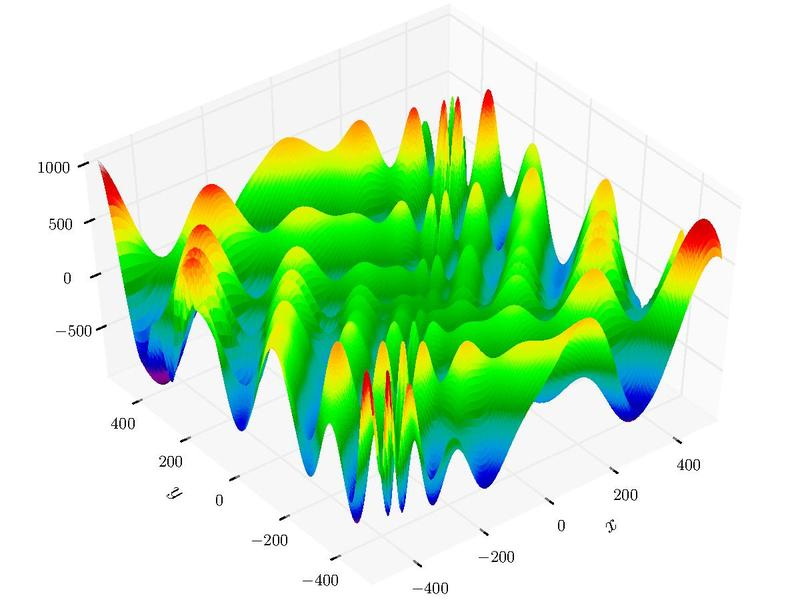

Global min at $f(512, 404.2319)$. By Gaortizg [GFDL](http://www.gnu.org/copyleft/fdl.html) or [CC BY-SA 3.0](http://creativecommons.org/licenses/by-sa/3.0), via Wikimedia Commons

# (Unconstrained) Optimization in `Julia`

- Umbrella Organisation: [`http://www.juliaopt.org`](http://www.juliaopt.org)
  - We will make ample use of this when we talk about constrained optimsation.
  - The Julia Interface to the very well established [C-Library NLopt](http://ab-initio.mit.edu/wiki/index.php/NLopt) is called [`NLopt.jl`](https://github.com/JuliaOpt/NLopt.jl). One could use `NLopt` without constraints in an unconstrained problem.
- [`Roots.jl`](https://github.com/JuliaLang/Roots.jl): Simple algorithms that find the zeros of a univariate function.
- Baseline Collection of unconstrained optimization algorithms: [`Optim.jl`](https://github.com/JuliaOpt/Optim.jl)

# Introducing [`Optim.jl`](https://github.com/JuliaOpt/Optim.jl)

- Multipurpose unconstrained optimization package
  - provides 8 different algorithms
  - univariate optimization without derivatives

### Introducing [Rosenbrock's Banana](https://en.wikipedia.org/wiki/Rosenbrock_function) function

The Banana function is defined by
$$f(x,y) = (a-x)^2 + b(y-x^2)^2$$

[figure not shown]

Banana for $a = 0$. By Gaortizg [GFDL](http://www.gnu.org/copyleft/fdl.html) or [CC BY-SA 3.0](http://creativecommons.org/licenses/by-sa/3.0), via Wikimedia Commons

### What is the minimum of that function?

- For $a=1,b=100$, what is the global minimum of that function?
- What are the inputs one needs to supply to an algorithm in a more general example?

# Rosenbrock Banana and Optim.jl

- We will use `Optim` for the rest of this lecture.
- We need to supply the objective function and - depending on the solution algorithm - the gradient and hessian as well.

```julia
function rosenbrock(x::Vector)
    return (1.0 - x[1])^2 + 100.0 * (x[2] - x[1]^2)^2
end

function rosenbrock_gradient!(x::Vector, storage::Vector)
    storage[1] = -2.0 * (1.0 - x[1]) - 400.0 * (x[2] - x[1]^2) * x[1]
    storage[2] = 200.0 * (x[2] - x[1]^2)
end

function rosenbrock_hessian!(x::Vector, storage::Matrix)
    storage[1, 1] = 2.0 - 400.0 * x[2] + 1200.0 * x[1]^2
    storage[1, 2] = -400.0 * x[1]
    storage[2, 1] = -400.0 * x[1]
    storage[2, 2] = 200.0
end
```

# Comparison Methods

```julia
# grid search on rosenbrock
grid = collect(-1.0:0.1:3);
grid2D = [[i;j] for i in grid,j in grid];
val2D = map(rosenbrock,grid2D);
r = findmin(val2D);
println("grid search results in minimizer = $(grid2D[r[2]])")
```

# The Golden Ratio or Bracketing Search for 1D problems

- A derivative-free method
- a Bracketing method
  - find the local minimum of $f$ on $[a,b]$
  - select 2 interior points $c,d$ such that $a<c<d<b$
    - $f(c) \leq f(d) \implies$ min must lie in $[a,d]$. replace $b$ with $d$, start again with $[a,d]$
    - $f(c) > f(d) \implies$ min must lie in $[c,b]$. replace $a$ with $c$, start again with $[c,b]$
  - how to choose $b,d$ though?
  - we want the length of the interval to be independent of whether we replace upper or lower bound
  - we want to reuse the non-replaced point from the previous iteration.
  - these imply the golden rule:
  - new point $x_i = a + \alpha_i (b-a)$, where $\alpha_1 = \frac{3-\sqrt{5}}{2},\alpha_2=\frac{\sqrt{5}-1}{2}$
  - $\alpha_2$ is known as the *golden ratio*, well known for it's role in renaissance art.

### Bracketing Search in Julia

- The package [`Optim.jl`](https://github.com/JuliaOpt/Optim.jl) provides an implementation of "Brent's Method" as well as the golden section search:

```julia
using Optim
using Gadfly
f(x) = exp(x) - x^4
minf(x) = -f(x)
plot(f,0,2)
brent = optimize(minf,0,2,method=:brent)
golden = optimize(minf,0,2,method=:golden_section)
```

- how well does this do with many local minima?

```julia
g(x) = exp(x) - x^4 +sin(40*x)
ming(x) = -g(x)
plot(g,0,2)
grid = collect(0:0.0001:2);
v,idx  = findmax(Float64[g(x) for x in grid])
println("grid maximizer is $(grid[idx])")
golden = optimize(ming,0,2,method=:golden_section)
brent = optimize(ming,0,2,method=:brent)
using Base.Test
@test_approx_eq  grid[idx] golden.minimum
@test_approx_eq  grid[idx] brent.minimum
```

- Not *very* well at all. You can easily see that this method only works for unimodal functions.
- We get trapped in a local minimum here.

# Bracketing for Multidimensional Problems: Nelder-Mead

- The Goal here is to find the simplex containing the local minimizer $x^*$
- In the case where $f$ is n-D, this simplex has $n+1$ vertices
- In the case where $f$ is 2-D, this simplex has $2+1$ vertices, i.e. it's a triangle.
- The method proceeds by evaluating the function at all $n+1$ vertices, and by replacing the worst function value with a new guess.
- this can be achieved by a sequence of moves:
  - reflect
  - expand
  - contract
  - shrink movements.

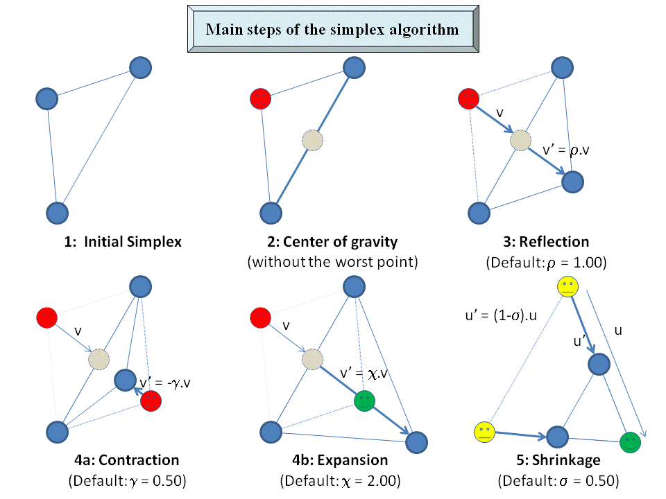

```julia
using Optim
optimize(rosenbrock, [0.0, 0.0], method = :nelder_mead)
```

- But.

# Bracketing for Multidimensional Problems: Comment on Nelder-Mead

> Lagarias et al. (SIOPT, 1999): At present there is no function in any dimension greater than one, for which the original Nelder-Mead algorithm has been proved to converge to a minimizer.

> Given all the known inefficiencies and failures of the Nelder-Mead algorithm [...], one might wonder why it is used at all, let alone why it is so extraordinarily popular.

# Reminder: Optimality Conditions

### Notation

- Unless otherwise noted, we have $x \in \mathbb{R}^n$ as an $n$ element vector.
- The **gradient** of a function $f : \mathbb{R}^n \mapsto \mathbb{R}$ is denoted $\nabla f:\mathbb{R}^n \mapsto \mathbb{R}^n$ a it returns a vector
  $$\nabla f(x) = \left(\frac{\partial f}{\partial x_1}(x),\frac{\partial f}{\partial x_2}(x),\dots,\frac{\partial f}{\partial x_n}(x) \right)$$
- It's **hessian** is a function denoted $\nabla^2 f(x)$ or $H_f :\mathbb{R}^n \mapsto \mathbb{R}^{n\times n}$ and returns an $(n,n)$ matrix given by
  $$H_f(x) = \left( \begin{array}{c} \frac{\partial^2 f}{\partial x_1 \partial x_1}(x) & \frac{\partial^2 f}{\partial x_2 \partial x_1}(x) & \dots & \frac{\partial^2 f}{\partial x_n \partial x_1}(x) \\
  \frac{\partial^2 f}{\partial x_1 \partial x_2}(x) & \frac{\partial^2 f}{\partial x_2 \partial x_2}(x) & \dots & \frac{\partial^2 f}{\partial x_n \partial x_2}(x) \\
  \vdots & \vdots & \dots & \vdots \\
  \frac{\partial^2 f}{\partial x_1 \partial x_n}(x) & \frac{\partial^2 f}{\partial x_2 \partial x_n}(x) & \dots & \frac{\partial^2 f}{\partial x_n \partial x_n}(x)
  \end{array}
  \right)$$

### Optimality Conditions

- **First Order Necessary Conditions**: If $f$ is continously differentiable and $x^*$ is a local minimizer of $f$, then $\nabla f(x^*) = 0$.
- **Second Order Necessary Conditions**: If $f$ is twice continuously differentiable and $x^*$ is a local minimizer of $f$, then $\nabla f(x^*) = 0$ *and* $H_f (x^*)$ is positive semi-definite, i.e. we have $s^T H_f (x^*) s \geq 0$ for all $s \in \mathbb{R}^n$.
- **Second Order Sufficient Conditions**: If $f$ is twice continuously differentiable and at $x^*$ we have that $\nabla f(x^*) = 0$ *and* $H_f (x^*)$ is positive definite, i.e. $s^T H_f (x^*) s > 0,s\neq 0$ then $x^*$ is a local minimizer of $f$.
- More sophisticated solvers make ample use of those.

# Reminder: Sufficient Conditions for Global Optimality

- If $f$ is convex, then any local minimizer $x^*$ is a global minimizer.
- If $f$ is convex and differentiable on $\mathbb{R}^n$ , then any point $x^*$ is a global minimizer if and only if it is a stationary point, i.e. if f$\nabla f(x^*) = 0$.

# Reminder: Taylor's Theorem

- Many of the ensuing methods are based on Taylor's theorem, so let's remind ourselves of it:
- Suppose that $f \in C^{n+1}[a,b]$, and $x,x^0 \in [a,b]$. Then
  $$\begin{align}
  f(x) = & f(x^0) + f'(x^0)(x - x^0) + f''(x^0)\frac{(x- x^0)^2}{2}\\
  + & \dots + f^{(n)}(x^0)\frac{(x - x^0)^n}{n!} + R_{n+1}(x)
  \end{align}$$
  where $R_{n+1}(x) = \mathcal{o}\left(\Vert (x-x^0) \Vert^{n+1}\right)$ is reminder term that converges at a rate $n+1$ to zero, i.e.
- we say a function $f$ is $\mathcal{o}(\Vert x \Vert^n)$ if $\lim_{x\to 0}\Vert f(x) \Vert / \Vert x \Vert^n =0$.
- we say a function $f$ is $\mathcal{O}(\Vert x \Vert^n)$ if $\lim_{x\to 0}\Vert f(x) \Vert / \Vert x \Vert^n < \infty$

# A quick Note on Computing Derivatives

- Finite Differences
- Automatic Differentiation
- We will talk about this in a separate session.
- For now just remember that if we don't supply analytic gradients, and the algorithm requires them, this often triggers a numerical approximation of the gradient known as finite differences. This is most of the times a slow proceedure.

# Two Strategies: Line Search and Trust Region

- We only provide an overview of methods here. If you want to *really* know the details about those algorithms, I invite you to consult (Nocedal and Wright 2006).

### The Line Search Strategy

- An algorithm from the line search class chooses a direction $p_k \in \mathbb{R}^n$ and searches along that direction starting from the current iterate $x_k \in \mathbb{R}^n$ for a new iterate $x_{k+1} \in \mathbb{R}^n$ with a lower function value.
- After deciding on a direction $p_k$, one needs to decide the *step length* $\alpha$ to travel by solving
  $$\min_{\alpha>0} f(x_k + \alpha p_k)$$
- In practice, solving this exactly is too costly, so algos usually generate a sequence of trial values $\alpha$ and pick the one with the lowest $f$.

### The Trust Region Strategy

- Here we construct a *model function* $m_k$ that is similar to $f$ around $x_k$.
- We acknowledge that $m_k$ is decent approximation of $f$ only in some *region*.
- The problem is then to find a candidate step length $p$ by solving
  $$\min_p m_k (x_k + p)$$
  where $x_k + p$ lies inside the trust region.
- If candidate $p$ does not produce a value lower than $f(x_k)$, we must have had a too large trust region, shrink it, and do it again.
- Usually the trust region is a ball $\Vert p \Vert_2 \leq \Delta$, where $\Delta$ is called the *trust region radius*, but elliptical and box regions are possible.
- A common definition of the model function is a quadratic of the form
  $$m_k(x_k + p) = f(x_k) + p^T \nabla f(x_k) + \frac{1}{2} p^T B(x_k) p$$
  where gradient and matrix $B(x_k)$ are evaluated at the current iterate, so the model function is in agreement to first order with $f$ at the current guess.
- The matrix $B(x_k)$ is either the Hessian $H_f$ or some approximation to it.

# Trust Region Example

- Suppose we have $f(x) = 10(x_2 - x_1^2)^2 + (1-x_1)^2$. At point $x_k= (0,1)$ gradient and hessian are:
- ?

$$\nabla f(x_k) = \left[ \begin{array}{c} -2 \\ 20 \end{array} \right], \quad \quad \nabla^2 f(x_k) = \left[ \begin{array}{c} -38 & 0 \\ 0 & 20 \end{array} \right]$$

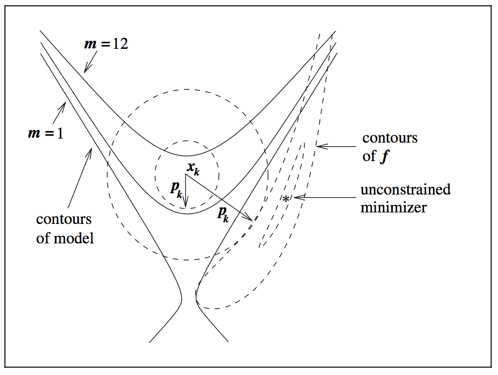

Figure 2.4 of (Nocedal and Wright 2006)

- In this figure, we use $B(x_k) = \nabla^2 f(x_k)$.
- After each unsuccesful step, the new candidate step will be shorter, and will go in a different direction
- This is the main difference to line search methods.
- Main difference between the two methods: order in which they change *direction* and *step length*
  - line search fixes direction $p_k$ and finds right distance $\alpha_k$
  - trust region fixes an appropriate radius $\Delta_k$

# Line Search Methods: Which Direction to go?

### Steepest Descent

- The direction $-\nabla f(x_k)$ is an obvious choice: Among all possible directions, along this one $f$ decreases most rapidly.
- This claim can be verified using Taylor's theorem.
- The **steepest descent method** is a line search method that moves along
  $$p_k = -\nabla f(x_k)$$
- The step length $\alpha_k$ can be chosen in many different ways.
- There are many other *descent* directions, steepest descent is but one of them.

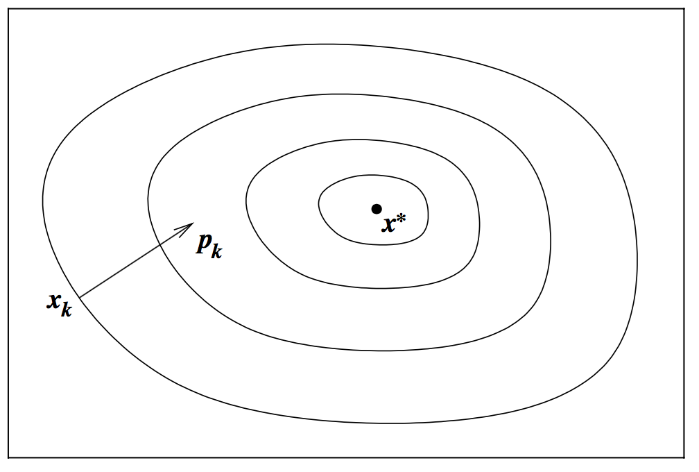

Figure 2.5 of (Nocedal and Wright 2006)

```julia
optimize(rosenbrock, rosenbrock_gradient!, [0.0, 0.0], method = :gradient_descent)
optimize(rosenbrock, rosenbrock_gradient!, [0.0, 0.0], method = :gradient_descent,iterations=5000)
optimize(rosenbrock, rosenbrock_gradient!, [0.0, 0.0], method = :gradient_descent,iterations=10000)
```

# Line Search Methods: The **Newton** Direction

- Probably the most important descent direction.
- In vector notation, the 2nd order taylor series approximation to $f(x_k + p)$ is
  $$f(x_k + p) \approx f(x_k) + p^T \nabla f(x_k) + \frac{1}{2} p^T \nabla^2 f(x_k) p \equiv m_k(p)$$
- the Newton direction is obtained by finding the vector $p$ that minimizes $m_k(p)$, i.e. by setting the derivative of $m_k(p)$ to zero.
- We obtain
  $$p_k^N = -(\nabla^2 f(x_k))^{-1} \nabla f(x_k)$$
- The newton direction is reliable if the discrepancy between truth and model $m$ is not too large at $x_k$.
- The biggest drawback is the need to compute the Hessian. This can be difficult analytically at times, and overly expensive numerically.

```julia
optimize(rosenbrock, rosenbrock_gradient!, rosenbrock_hessian!, [0.0, 0.0], method = :newton)
```

# Quasi-Newton Methods

- In response to the difficulties of getting the Hessian, quasi-newton methods propose to approximate $B(x_k)$ with something *similar* to the hessian.
- Taylors Theorem implies that
  $$\nabla^2 f(x_{k+1} - x_{k}) \approx \nabla f(x_{k+1}) - \nabla f(x_k)$$
  and so we choose a $B$ matrix that mimics this property.
- This leads to the *secant condition*
  $$B_{k+1} (x_{k+1} - x_{k}) = f(x_{k+1}) - \nabla f(x_k)$$
- There are different ways to update the hessian in this way.
- One of the best known is the BFGS method (after Broydon, Fletcher, Goldfarb and Shanno).
- Those methods get the search direction by using $B_k$ instead of the exact Hessian, i.e.
  $$p_k = -B_k^{-1} \nabla f(x_k)$$

```julia
optimize(rosenbrock, rosenbrock_gradient!, rosenbrock_hessian!, [0.0, 0.0], method = :bfgs)
# low memory BFGS
optimize(rosenbrock, rosenbrock_gradient!, rosenbrock_hessian!, [0.0, 0.0], method = :l_bfgs)
```

# Practical Considerations

## Stopping criteria

- In all of the above examples, we did not alter the default values for stopping criteria.
- There are different things you could focus on as a stopping criterion with `Optim`, and similarly in most solver packages.
  - `xtol`: changes in $x$ from one iterate to the next
  - `ftol`: perentage changes in $f$ from one iterate to the next
  - `grtol`: absolute value of the gradient beign smaller than this number.

# Some Applications in Economics

- Maximum Likelihood Estimation
- The Nested Fixed Point Algorithm
  - (Rust 1987) is a maximum likelihood estimation with an inner loop that solves a dynamic programming problem.
  - (Berry et al. 1995) is a GMM estimation with an inner fixed point problem.

# References

Berry, S., Levinsohn, J., & Pakes, A. (1995). Automobile prices in market equilibrium. *Econometrica: Journal of the Econometric Society*, 841–890.

Nocedal, J., & Wright, S. (2006). *Numerical optimization*. Springer Science & Business Media.

Robert, C., & Casella, G. (2009). *Introducing monte carlo methods with r*. Springer Science & Business Media.

Rust, J. (1987). Optimal replacement of gMC bus engines: An empirical model of harold zurcher. *Econometrica*, *55*(5), 999–1033. http://www.jstor.org/stable/1911259